# Useuful Skills in ggplot2

Let’s start with a finished example:

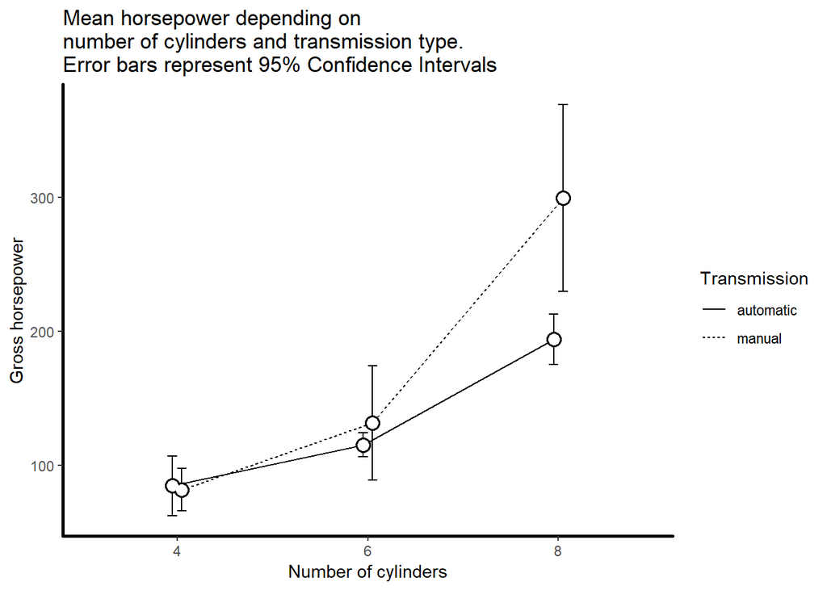

```r
library(dplyr)
library(ggplot2)

pd <- position_dodge(width = 0.1)
mtcars %>%
  mutate(cyl = factor(cyl), am = factor(am, labels = c("automatic", "manual"))) %>%
  group_by(cyl, am) %>%
  summarise(hp_mean = mean(hp),
            hp_ci   = 1.96 * sd(hp)/sqrt(n())) %>%
  ggplot(aes(x = cyl, y = hp_mean, group = am)) +
    geom_line(aes(linetype = am), position = pd) +
    geom_errorbar(aes(ymin = hp_mean - hp_ci, ymax = hp_mean + hp_ci),
                  width = .1, position = pd, linetype = 1) +
    geom_point(size = 4, position = pd) +
    geom_point(size = 3, position = pd, color = "white") +
    guides(linetype = guide_legend("Transmission")) +
    labs(title = paste("Mean horsepower depending on",
                       "number of cylinders and transmission type.",
                       "Error bars represent 95% Confidence Intervals",
                       sep = "\n"),
         x = "Number of cylinders",
         y = "Gross horsepower") +
  theme(
    panel.background = element_rect(fill = "white"),
    legend.key  = element_rect(fill = "white"),
    axis.line.x = element_line(colour = "black", size = 1),
    axis.line.y = element_line(colour = "black", size = 1)
  )
```

Let’s break this down.

## Summarising the data

We’ll be working with the `mtcars` dataset which comes with R and contains various information about 32 cars from 1974. Here, we’re interested in plotting the mean gross horsepower (`hp`) as a function of two categorical variables: the number of cylinders (`cyl`) and the transmission type (`am`). As a quick aside, note that this example will, therefore, be directly applicable to plotting the mean of a continuous variable grouped by two categorical variables.

Let’s focus on the relevant columns and convert the grouping variables to factors. To do this, we’ll use `select()` and `mutate()` from the [`dplyr`](https://cran.r-project.org/web/packages/dplyr/index.html) package. We won’t bother giving `cyl` labels (as they’re already the numbers we want), but we’ll label `am` so we don’t need to worry about converting 0s and 1s in our head.

```r
library(dplyr)
d <- mtcars %>%
       select(cyl, am, hp) %>%  # select relevant variables
       mutate(cyl = factor(cyl),  # Convert grouping variables to factors
              am  = factor(am, labels = c("automatic", "manual")))

head(d)
```

```
##   cyl        am  hp
## 1   6    manual 110
## 2   6    manual 110
## 3   4    manual  93
## 4   6 automatic 110
## 5   8 automatic 175
## 6   6 automatic 105
```

We need the mean horsepower for each cylinder-transmission combination. This is best achieved with a couple more functions from [`dplyr`](https://cran.r-project.org/web/packages/dplyr/index.html): group the data by the factors with `group_by()`, and `summarise()` to compute the means:

```r
d %>%
  group_by(cyl, am) %>%
  summarise(hp_mean = mean(hp))
```

```
## # A tibble: 6 x 3
## # Groups:   cyl [?]
##   cyl   am        hp_mean
##   <fct> <fct>       <dbl>
## 1 4     automatic    84.7
## 2 4     manual       81.9
## 3 6     automatic   115.
## 4 6     manual      132.
## 5 8     automatic   194.
## 6 8     manual      300.
```

We now have a mean column which represents where the points will go on in the plot. Let’s also compute the distance from the mean to the 95% confidence interval (`hp_ci`) in anticipation of the error bars and save the resulting data frame:

```r
sum_d <- d %>%
          group_by(cyl, am) %>%
          summarise(hp_mean = mean(hp),
                    hp_ci   = 1.96 * sd(hp)/sqrt(n()))
sum_d
```

```
## # A tibble: 6 x 4
## # Groups:   cyl [?]
##   cyl   am        hp_mean hp_ci
##   <fct> <fct>       <dbl> <dbl>
## 1 4     automatic    84.7 22.2
## 2 4     manual       81.9 15.7
## 3 6     automatic   115.   9.00
## 4 6     manual      132.  42.5
## 5 8     automatic   194.  18.9
## 6 8     manual      300.  69.6
```

For those a little rusty with statistics, `sd(hp)/sqrt(n())` gives us the standard error of the mean, and multiplying this by 1.96 gives us the distance from the mean to the 95% interval boundary (which we then add or subtract from the mean).

Great, we’ve now got a data frame of the information we need to produce the plot.

## Creating the plot

To create the plot, we’ll use the [`ggplot2`](https://cran.r-project.org/web/packages/ggplot2/index.html) package. When you create a plot with `ggplot2`, you build up layers of graphics. It’s important to keep this idea of layering in mind as we gradually build the plot.

### Setup

To start, we’ll set up a blank plot canvas with relevant x and y-axes using `ggplot()`:

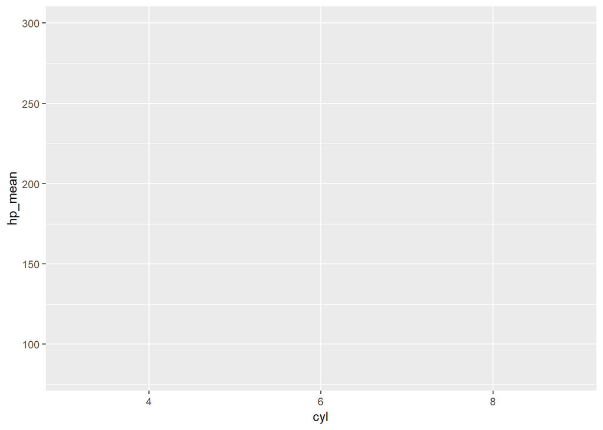

```r
sum_d %>%
  ggplot(aes(x = cyl, y = hp_mean))
```

### Adding points

Next, we want to represent our data in our plot. `ggplot2` uses various geoms to do this, which are layered into the plot using `+`. Let’s start with the points themselves by using `geom_point()`:

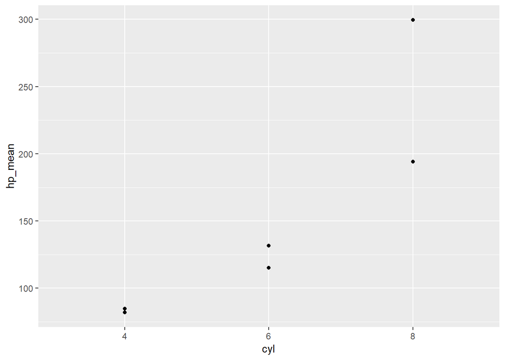

```r
sum_d %>%
  ggplot(aes(x = cyl, y = hp_mean)) +
    geom_point()
```

### Adding lines

Next we’ll add the lines with `geom_line()`:

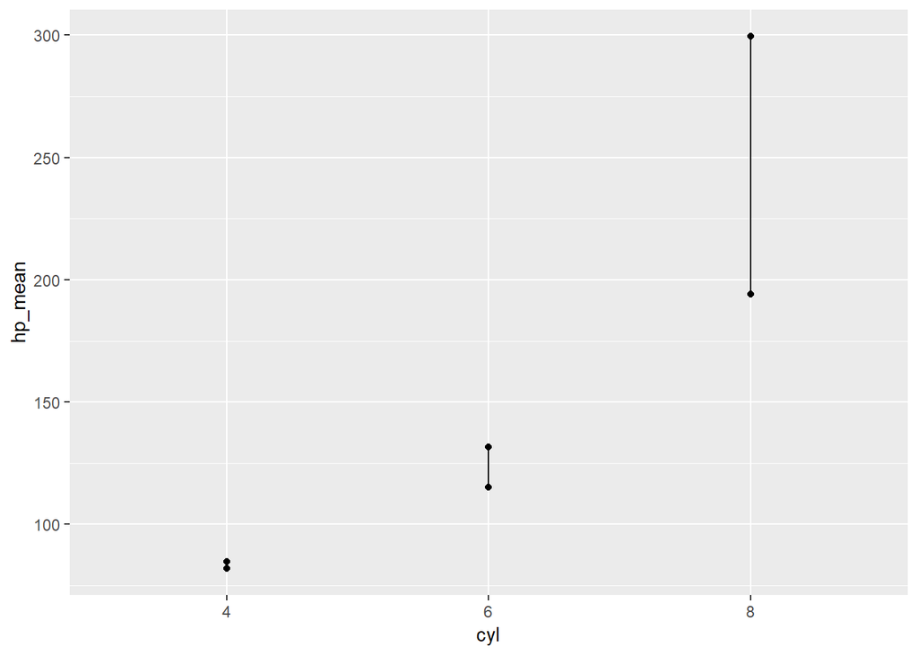

```r
sum_d %>%
  ggplot(aes(x = cyl, y = hp_mean)) +
    geom_point() +
    geom_line()
```

The problem is that we haven’t specified that the lines should be grouped by transmission, so it’s just using the already provided number of cylinders. To handle this, we assign the `group` and `linetype` aesthetics to our second categorical variable, `am`. Note that `group` is handled in `ggplot`, but `linetype` is in `geom_line()`. These can be moved around, but having `group` in `ggplot` is important for the position adjustment discussed later.

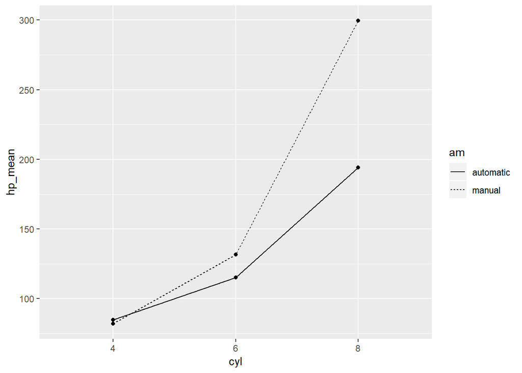

```r
sum_d %>%
  ggplot(aes(x = cyl, y = hp_mean, group = am)) +
    geom_point() +
    geom_line(aes(linetype = am))
```

### Adding error bars

The last visual element to add is the error bars using `geom_errorbar()`, which requires us to specify `ymin` and `ymax` for each error bar. I like to do the calculation within this function as follows:

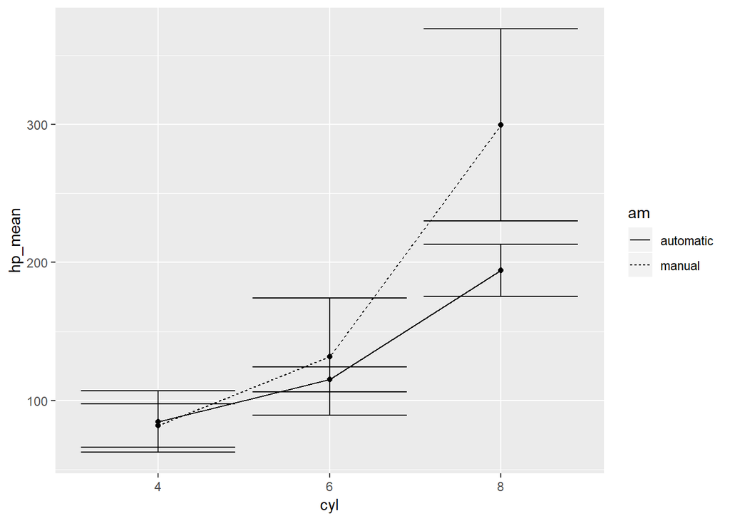

```r
sum_d %>%
  ggplot(aes(x = cyl, y = hp_mean, group = am)) +
    geom_point() +
    geom_line(aes(linetype = am)) +
    geom_errorbar(aes(ymin = hp_mean - hp_ci, ymax = hp_mean + hp_ci))
```